Author: @Alex Qian(wenzhang@ualberta.ca)

# Welcome to your interactive tutorial of Jupyter notebook, Numpy and OpenCV

## Jupyter notebook

- launch
- run a cell
- code <---> markdown
- toolbar
- command palette
- keyboard shortcuts
- (magic keywords)

### launch

`jupyter notebook` or `jupyter notebook tutorial.ipynb` in the terminal.

Potential error for the dependency. Install all the packagees.

If you are using my Starter-Kit, use `source activate robo` on Mac OS/ Linux or `activate robo` on Windows

The server runs at http://localhost:8888 by default.

### run a cell

Add code in a cell and use "shift + enter" to run it.

### Quiz:

Print Hello World

### cell types

Only code cells and markdown cells will be covered in this tutorial.

You just made a code cell. Let's create a markdown cell.

There can be

# Header 1

## Header 2

### Header 3

[Author's Github profile](https://github.com/AlexQian97)

*italics* or *italics*

**bold** or **bold** $$ y = \frac{a}{b+c} $$ I am not good at LaTex, I am not goint to continue on the math expression. Anyway, you can always find resources on Google.

### toolbar

Just go through all icons

- The anachronistic symbol for "save," the floppy disk. Saves the notebook!
- The + button creates a new cell
- Then, buttons to cut, copy, and paste cells.
- Run, stop, restart the kernel
- Cell type: code, Markdown, raw text, and header
- Command palette (see next)
- Cell toolbar, gives various options for cells such as using them as slides

Three cells below are intentionally left empty for you to test these functions.

### command palette

Just one more thing, I wish you could add a html file of your notebook so that people do not have to open your notebook with command line to just have a look.

My tutorial is just a crush course, if you want to learn more about Jupyter notebook. This is the offical website of [Jupyter](http://jupyter.org). You can find documents and tutorial about Jupyter on it.

# Good job, you have done the Jupyter notebook tutorial. Let's do some Numpy.

Numpy is a library adding support for large, multi-dimensional arrays and matrices, along with a large collection of high-level mathematical functions to operate on these arrays.

In short, a high-performace math library.

First, let's make a matrix.

```python
import numpy as np
a = np.arange(15).reshape(3, 5)
print(a)
```

```
[[ 0  1  2  3  4]
 [ 5  6  7  8  9]
 [10 11 12 13 14]]
```

What?! You think that is too fast?! Okay, let's start with array because matrix is just a array of arrays.

```python
import numpy as np
# This is a list
im_list = [1, 2, 3]
# This is a numpy array
im_np_array = np.array(im_list)
print(im_np_array)
print(type(im_np_array))
```

```
[1 2 3]
<type 'numpy.ndarray'>
```

### Quiz:

create a list of your birthday [yyyy, mm, dd] and make it a numpy array.

```python
birthday = [1997, 6, 16]
birthday = np.array(birthday)
```

Good job, you just created your first numpy array. Let's have a closer look at numpy array.

```python
birthday.dtype
```

```
dtype('int64')
```

Append a float number GPA to it using `np.append([list], [list])`

```python
np.append(birthday, 4.0)
```

```
array([ 1997.,     6.,    16.,     4.])
```

```python
birthday.dtype
```

```
dtype('int64')
```

Obviously, Numpy Array can only store one and only one datatype.

### Then, let's do some basic math. Run the following cells and try to understand the logic behind Numpy.

```python
a = np.array([20, 30, 40, 50])
b = np.arange(4)
print(a)
print(b)
```

```
[20 30 40 50]
[0 1 2 3]
```

```python
# + an array
a + b
```

```
array([20, 31, 42, 53])
```

```python
# - an array
a - b
```

```
array([20, 29, 38, 47])
```

```python
# *
a * b
```

```
array([  0,  30,  80, 150])
```

```python
# /
a / b
```

```
array([ 0, 30, 20, 16])
```

### matrix operations

```python
# what if the size if not same
c = np.arange(3)
print(c)
print("=========")
a + c
```

```
[0 1 2]
=========
```

```
---------------------------------------------------------------------------
ValueError                                Traceback (most recent call last)
<ipython-input-24-696d5144e7f8> in <module>()
      3 print(c)
      4 print("=========")
----> 5 a + c

ValueError: operands could not be broadcast together with shapes (4,) (3,)
```

Obviously, all operations are elementwise if both a and b are numpy arrays with the same size.

```python
a + 1
```

```
array([21, 31, 41, 51])
```

```python
a * 2
```

```
array([ 40,  60,  80, 100])
```

Tell them that your English is too poor to describe it.

We can talk about matrix after you understand array.

A matrix is just an array of arrays

```python
Im_matrix = np.array([[1, 2],
                      [3, 4]])
print(Im_matrix)
print(Im_matrix.shape)
print(Im_matrix.dtype)
```

```
[[1 2]
 [3 4]]
(2, 2)
int64
```

```python
Im_matrix = np.arange(4).reshape(2, 2)
print(Im_matrix)
```

```
[[0 1]
 [2 3]]
```

### Quiz: create a matrix of any size.

I know this quiz is dumb but I just want to make sure you are still with me.

### The following methods are useful when dealing with masks. ATTENTION.

```python
ones = np.ones((2, 3), dtype=int)
print(ones)
```

```
[[1 1 1]
 [1 1 1]]
```

```python
zeros = np.zeros((2, 3), dtype=int)
print(zeros)
```

```
[[0 0 0]
 [0 0 0]]
```

```python
random_noise = np.random.random((2, 3))
print(random_noise)
print(random_noise.sum())
print("================")
print(random_noise.sum(axis=0))
print(random_noise.sum(axis=1))
print("================")
print(random_noise.min())
print(random_noise.max())
```

```
[[ 0.02407683  0.02927025  0.58491834]
 [ 0.5029049   0.63092707  0.78035595]]
2.55245334585
================
[ 0.52698173  0.66019732  1.36527429]
[ 0.63826542  1.91418792]
================
0.024076830538
0.780355951025
```

```python
spaced = np.linspace(0, 10, 5)
print(spaced)
```

```
[  0.    2.5   5.    7.5  10. ]
```

### matrix operations

```python
a = b = np.arange(4).reshape(2,2)
print(a)
a.dot(b)
```

```
[[0 1]
 [2 3]]
```

```
array([[ 2,  3],
       [ 6, 11]])
```

```python
a = [1, 2, 3]
b = [4, 5 ,6]
np.cross(a, b)
```

```
array([-3,  6, -3])
```

```python
a = np.array([1, 2, 3])
b = np.array([4, 5 ,6])
np.cross(a, b)
```

```
array([-3,  6, -3])
```

### Indexing, Slicing, Iterating

```python
a = np.arange(10) ** 3
print(a)
```

```
[  0   1   8  27  64 125 216 343 512 729]
```

```python
a[2]
```

```
8
```

```python
a[2:5]
```

```
array([ 8, 27, 64])
```

```python
a[:6:2]
```

```
array([ 0,  8, 64])
```

```python
Im_matrix = np.arange(25).reshape(5, 5)
print(Im_matrix)
```

```
[[ 0  1  2  3  4]
 [ 5  6  7  8  9]
 [10 11 12 13 14]
 [15 16 17 18 19]
 [20 21 22 23 24]]
```

```python
Im_matrix[2:5, 2:5]
```

```
array([[12, 13, 14],
       [17, 18, 19],
       [22, 23, 24]])
```

## Congratulations, you have done the Numpy totorial. After that, we can do some computer vision with OpenCV.

### First, we need to load the image

```python
import cv2
image = cv2.imread('test_images/frame1.png')
cv2.imshow('image', image)
cv2.waitKey(0)
cv2.destroyAllWindows()
```

Ooops, it seems `cv2.imshow()` does not work with Jupyter notebook very well

[figure not shown]

```python
import cv2
import matplotlib.pyplot as plt
%matplotlib inline

image = cv2.imread('test_images/frame1.png')
plt.imshow(image)
```

[figure not shown]

```python
# First, cvtcolor before imshow
import cv2
import matplotlib.pyplot as plt
%matplotlib inline

image = cv2.imread('test_images/frame1.png')
image = cv2.cvtColor(image, cv2.COLOR_RGB2BGR)
plt.figure(figsize=(20,10))
plt.imshow(image)
```

[figure not shown]

```python
# Second, use plt.imread and plt.imshow
import cv2
import matplotlib.pyplot as plt
%matplotlib inline

image = plt.imread('test_images/frame1.png')
plt.figure(figsize=(20,10))
plt.imshow(image)
```

### Because you have known how to load a image, a quiz will help me make sure everyone is will me.

### Quiz: load any image in /test_images and plot it in notebook.

### Now, it is time to show you when I need to teach Numpy before OpenCV

```python
print(type(image))
print(image.shape)
```

```
<type 'numpy.ndarray'>
(720, 1280, 3)
```

Oh, it is an numpy array! So every operation you have learnt can be applied to images.

### Region of interest

[figure not shown]

```python
import cv2
import numpy as np
import matplotlib.pyplot as plt
%matplotlib inline

plt_image = plt.imread('test_images/frame1.png')

def region_of_interest(img, vertices):
    """
    Applies an image mask.

    Only keeps the region of the image defined by the polygon
    formed from `vertices`. The rest of the image is set to black.
    """
    #defining a blank mask to start with
    mask = np.zeros_like(img)

    #defining a 3 channel or 1 channel color to fill the mask with depending on the input image
    if len(img.shape) > 2:
        channel_count = img.shape[2]  # i.e. 3 or 4 depending on your image
        ignore_mask_color = (255,) * channel_count
    else:
        ignore_mask_color = 255

    #filling pixels inside the polygon defined by "vertices" with the fill color
    cv2.fillPoly(mask, vertices, ignore_mask_color)

    #returning the image only where mask pixels are nonzero
    masked_image = cv2.bitwise_and(img, mask)
    return masked_image

#vertices = np.array([[(0, 420),(0, 70),(1070, 70), (1070, 220), (1280, 220), (1280, 420)]], dtype=np.int32)
vertices = np.array([[(300, 420), (300, 70), (900, 70), (900, 420)]], dtype=np.int32)
masked_image = region_of_interest(plt_image, vertices)
plt.figure(figsize=(20,10))
plt.imshow(masked_image)
```

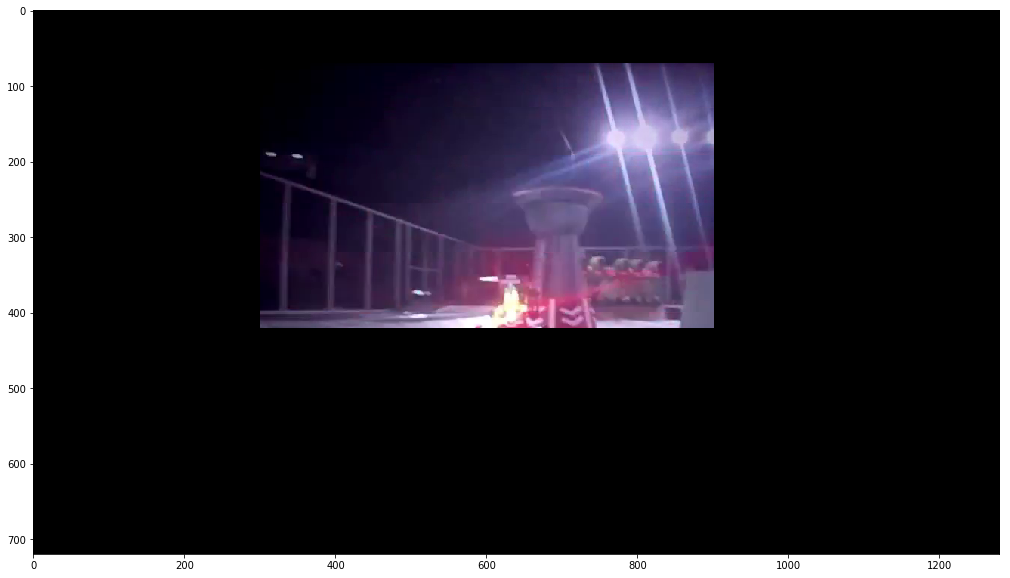

```python
cv2_image = cv2.imread('test_images/frame1.png')
cv2_image = cv2.cvtColor(cv2_image, cv2.COLOR_RGB2BGR)

masked_image = region_of_interest(cv2_image, vertices)
plt.figure(figsize=(20,10))
plt.imshow(masked_image)
```

[output not shown]

```python
plt_image == cv2_image
```

```
array([[[ True,  True,  True],
        [ True,  True,  True],
        [ True,  True,  True],
        ...,
        [ True,  True,  True],
        [ True,  True,  True],
        [ True,  True,  True]],

       [[ True,  True,  True],
        [ True,  True,  True],
        [ True,  True,  True],
        ...,
        [ True,  True,  True],
        [ True,  True,  True],
        [ True,  True,  True]],

       [[ True,  True,  True],
        [ True,  True,  True],
        [ True,  True,  True],
        ...,
        [ True,  True,  True],
        [ True,  True,  True],
        [ True,  True,  True]],

       ...,
       [[ True,  True,  True],
        [ True,  True,  True],
        [ True,  True,  True],
        ...,
        [ True,  True,  True],
        [ True,  True,  True],
        [ True,  True,  True]],

       [[ True,  True,  True],
        [ True,  True,  True],
        [ True,  True,  True],
        ...,
        [ True,  True,  True],
        [ True,  True,  True],
        [ True,  True,  True]],

       [[ True,  True,  True],
        [ True,  True,  True],
        [ True,  True,  True],
        ...,
        [ True,  True,  True],
        [ True,  True,  True],
        [ True,  True,  True]]], dtype=bool)
```

### Convert color channel

```
(720, 1280)
```

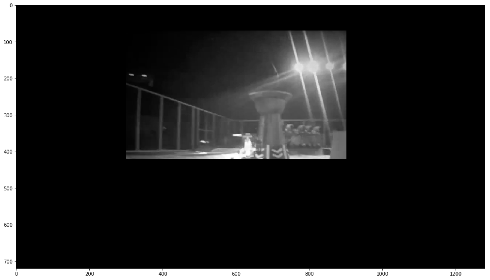

```python
gray = cv2.cvtColor(masked_image, cv2.COLOR_BGR2GRAY)
print(gray.shape)
plt.figure(figsize=(20,10))
plt.imshow(gray, cmap='gray')
```

### Quiz: play with cvtColor()

Colorspaces: BGR, RGB, GRAY, Luv, HSV, HLS

Three popular color spaces are attached.

[figure not shown]

### HSV is very robust in different lighting condition. As a result, it should be your default choice when using color spaces.

```python
image = cv2.imread('test_images/frame1.png')
image = cv2.cvtColor(image, cv2.COLOR_RGB2BGR)

R = image[:,:,0]
G = image[:,:,1]
B = image[:,:,2]
hls = cv2.cvtColor(image, cv2.COLOR_BGR2HSV)
H = hls[:,:,0]
S = hls[:,:,1]
V = hls[:,:,2]
```

```
([], <a list of 0 Text yticklabel objects>)
```

[figure not shown]

```python
plt.figure(figsize=(30,10))
font_size = 40
plt.subplot(231)
plt.imshow(R, cmap='gray')
plt.title('R', fontsize=font_size)
plt.xticks([])
plt.yticks([])

plt.subplot(232)
plt.imshow(G, cmap='gray')
plt.title('G', fontsize=font_size)
plt.xticks([])
plt.yticks([])

plt.subplot(233)
plt.imshow(B, cmap='gray')
plt.title('B', fontsize=font_size)
plt.xticks([])
plt.yticks([])

plt.subplot(234)
plt.imshow(H, cmap='gray')
plt.title('H', fontsize=font_size)
plt.xticks([])
plt.yticks([])

plt.subplot(235)
plt.imshow(S, cmap='gray')
plt.title('S', fontsize=font_size)
plt.xticks([])
plt.yticks([])

plt.subplot(236)
plt.imshow(V, cmap='gray')
plt.title('V', fontsize=font_size)
plt.xticks([])
plt.yticks([])
```

### Then, let's do some color thresholding. I will use RGB color space because it is more natural for beginners.

```python
def rgb_select(image, thresh=(0, 255), color='b'):
    if color == 'b':
        color_channel = image[:,:,2]
    elif color == 'r':
        color_channel = image[:,:,0]

    binary_output = np.zeros_like(color_channel)
    binary_output[(color_channel > thresh[0]) & (color_channel <= thresh[1])] = 1
    return binary_output

def gray_threshold(image, thresh=(0, 255)):
    binary_output = np.zeros_like(image)
    binary_output[(image > thresh[0]) & (image <= thresh[1])] = 255
    return binary_output
```

[figure not shown]

```python
rgb_binary = rgb_select(image, thresh=(175, 255), color='r')
plt.figure(figsize=(20,10))
plt.imshow(rgb_binary)
```

[figure not shown]

```python
gray_image = cv2.cvtColor(image, cv2.COLOR_RGB2GRAY)
gray_binary = gray_threshold(gray_image, thresh=(175, 255))
plt.figure(figsize=(20, 10))
plt.imshow(gray_binary)
```

### Color thresholds can be used to detected specfic range of color. However, we need to find some specifc shape or boundray from time to time. The last topic of this tutorial is about edge detection.

[figure not shown]

```python
edges = cv2.Canny(gray_image,100,200)
plt.figure(figsize=(20,10))
plt.imshow(edges)
```

[figure not shown]

```python
edges = cv2.Canny(gray_image,100,500)
plt.figure(figsize=(20,10))
plt.imshow(edges)
```

```python
def mag_thresh(image, sobel_kernel=3, mag_thresh=(0, 255)):
    # Calculate gradient magnitude
    # Convert to grayscale
    gray = cv2.cvtColor(image, cv2.COLOR_RGB2GRAY)
    # Take both Sobel x and y gradients
    sobelx = cv2.Sobel(gray, cv2.CV_64F, 1, 0, ksize=sobel_kernel)
    sobely = cv2.Sobel(gray, cv2.CV_64F, 0, 1, ksize=sobel_kernel)
    # Calculate the gradient magnitude
    gradmag = np.sqrt(sobelx**2 + sobely**2)
    # Rescale to 8 bit
    scale_factor = np.max(gradmag)/255
    gradmag = (gradmag/scale_factor).astype(np.uint8)
    # Create a binary image of ones where threshold is met, zeros otherwise
    binary_output = np.zeros_like(gradmag)
    binary_output[(gradmag >= mag_thresh[0]) & (gradmag <= mag_thresh[1])] = 1

    # Return the binary image
    return binary_output

def dir_threshold(image, sobel_kernel=3, thresh=(np.pi/4, np.pi*3/4)):
    # Calculate gradient direction
    # Grayscale
    gray = cv2.cvtColor(image, cv2.COLOR_RGB2GRAY)
    # Calculate the x and y gradients
    sobelx = cv2.Sobel(gray, cv2.CV_64F, 1, 0, ksize=sobel_kernel)
    sobely = cv2.Sobel(gray, cv2.CV_64F, 0, 1, ksize=sobel_kernel)
    # Take the absolute value of the gradient direction,
    # apply a threshold, and create a binary image result
    absgraddir = np.arctan2(np.absolute(sobely), np.absolute(sobelx))
    binary_output =  np.zeros_like(absgraddir)
    binary_output[(absgraddir >= thresh[0]) & (absgraddir <= thresh[1])] = 1

    # Return the binary image
    return binary_output
```

[figure not shown]

```python
ksize = 9 # Choose a larger odd number to smooth gradient measurements

mag_binary = mag_thresh(image, sobel_kernel=ksize, mag_thresh=(30, 255))
plt.figure(figsize=(20,10))
plt.imshow(mag_binary)
```

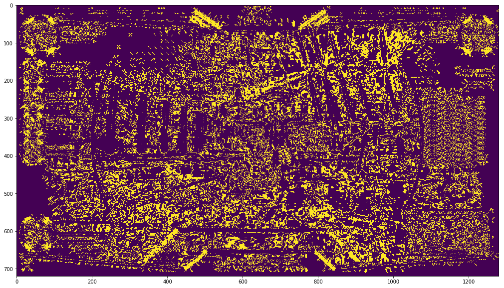

```python
dir_binary = dir_threshold(image, sobel_kernel=ksize, thresh=(0.7, 1.2))
plt.figure(figsize=(20,10))
plt.imshow(dir_binary)
```

### Different binary masks can be combined for better performance.

[figure not shown]

```python
combined = np.zeros_like(rgb_binary)
plt.figure(figsize=(20,10))
combined[(rgb_binary == 1) & (gray_binary == 255)] = 1
plt.imshow(combined)
```

# This is the end of this tutorial. You have just learnt the basic computer vision techniques. Good luck with you mini projects!

### There is one more thing. Please add a .html file as well